# assignment week 5

Sarah Eiben

2022-03-24

Questions: Where do directories we create automatically get saved? In the place you save the file? Why is it not shown in the “files” tab on the right? Why do we have to save the things from ENCODE with .gz in the end and not just e.g. .bed? Can you move/copy files in your folders for them to be accessible by a new Markdown document? What exactly are seqlevels? When do we have to use the double colon?

```r
suppressPackageStartupMessages({
  library(AnnotationHub)
  library(Rsubread)
  library(rtracklayer)
  library(Biostrings)
  library(Rfastp)
  library(epiwraps)
})
ah <- AnnotationHub()
```

```
## snapshotDate(): 2021-10-20
```

```r
ensdb <- ah[["AH89211"]]
```

```
## loading from cache
```

```
## require("ensembldb")
```

## Downloading the raw reads

```r
dir.create("raw")
download.file("https://www.encodeproject.org/files/ENCFF001LJN/@@download/ENCFF001LJN.fastq.gz", dest="raw/Mouse.fastq.gz" )
```

## Trimming with Rfastp

```r
dir.create("rfastp.trimmed")
#The first "" is the input file names, then outputFastq is the string of path for the output
qc <- Rfastp::rfastp("raw/Mouse.fastq.gz", outputFastq="rfastp.trimmed/Mouse",                maxNfilter=0, thread=4, overrepresentationAnalysis=TRUE)
```

## Generate the qc plot inside the markdown

```r
Rfastp::curvePlot(qc, curve="content_curves")
```

[output not shown]

## Just for me to see what this one puts out

```r
Rfastp::curvePlot(qc, curve="quality_curves")
```

[output not shown]

# Alignment (Using Rsubread)

Before we can do peak analysis we have to align the reads.

## First we have to build a genome index for mapping

```r
# we get the genome sequence from AnnotationHub
genome <- ah[["AH88477"]]
# we create a new directory that will contain the genome index
dir.create("mouse_genome")
# we write the genome sequence in fasta format
export(import.2bit(genome), "mouse_genome/genome.fasta.gz", compress=TRUE)
# we build a Rsubread index
Rsubread::buildindex("mouse_genome/rsubread", reference="mouse_genome/genome.fasta.gz", gappedIndex=TRUE, indexSplit=TRUE)
```

## Now we can align our reads to this genome

```r
dir.create("aligned")
#specify the index, specify if either dna or cdna, specify the output and the input file (use trimmed one for input), specify number of threads used for this
align.stats <- Rsubread::align(index="mouse_genome/rsubread", type="dna", output_file="aligned/Mouse.bam", readfile1="rfastp.trimmed/Mouse_R1.fastq.gz",
nthreads=4, sortReadsByCoordinates=TRUE)
align.stats
```

[output not shown]

## Peak calling

Identify which parts are peaks.

```r
library(epiwraps)
#works nicely for clear peaks but is critical for borderline peaks
peaks <- callPeaks("aligned/Mouse.bam")
```

```
## Getting coverage across sliding windows...
```

```
## Evaluating neighborhoods...
```

```
## Removing overlapping peaks...
```

```r
# if we want to save it as a bed file:
#rtracklayer::export.bed(peaks, "peaks/peaks.bed")
peaks
```

```
## GRanges object with 26048 ranges and 2 metadata columns:
##           seqnames            ranges strand |     score     p.value
##              <Rle>         <IRanges>  <Rle> | <numeric>   <numeric>
##       [1]        1   3670551-3670800      * |   2.63381 4.68469e-06
##       [2]        1   3994701-3994950      * |   3.13904 1.97871e-09
##       [3]        1   4150801-4151050      * |   3.21042 5.23499e-08
##       [4]        1   4544101-4544350      * |   2.58760 5.77986e-11
##       [5]        1   4598451-4598700      * |   2.43450 4.69494e-05
##       ...      ...               ...    ... .       ...         ...
##   [26044]        Y 90801351-90801600      * |   2.83705 4.41989e-05
##   [26045]        Y 90803551-90803800      * |   1.58785 4.46360e-05
##   [26046]        Y 90804951-90805200      * |   3.44112 1.72281e-08
##   [26047]        Y 90807501-90807750      * |   3.73825 5.94366e-14
##   [26048]        Y 90808601-90808850      * |   3.83705 1.00265e-11
##   -------
##   seqinfo: 66 sequences from an unspecified genome
```

```r
sum(table(peaks))
```

```
## [1] 26048
```

We find 26048 peaks.

# Bam to bigwig

Generating coverage tracks (only gives an invisible file as output)

```r
library(epiwraps)
dir.create("tracks")
#binWidth=10 --> less detailed, makes large files easier to be analyzed
#the binwidth just changes the resolution (bigger values mean coarser signal, but small file sizes), extend=50 is because in that experiment the fragments were 50-100bp, scaling=TRUE (which is the default) is to make signals more comparable across experiments, so it's not very important when you're dealing with just one file. But I do it systematically because you might decide to compare things later on...
bam2bw("aligned/Mouse.bam", "tracks/Mouse_full.bw", binWidth=10, extend=100, scaling=TRUE)
```

# Looking at an example peak

```r
#If it's coordinates of a region, it can either be a string of the format seqname:start-end (e.g. "chr2:10000:10500"), or a GRanges of length one. This means, for example, that if you have a peaks object that contains your peaks, you could visualize them one by one by giving region=peaks[1] (and  region=peaks[2] for the second, etc)
plotSignalTracks(list(bigwig="tracks/Mouse_full.bw", bam="aligned/Mouse.bam", peaks=peaks), region=peaks[1], extend=500)
```

[output not shown]

```r
plotSignalTracks(list(bigwig="tracks/Mouse_full.bw", bam="aligned/Mouse.bam", peaks=peaks), region="hprt", ensdb = ensdb, extend=1000)
```

[output not shown]

Estimated time for assignment completion: 7 hours

# Download the peaklevel-data from ENCODE

The following order: H3K4me3, H3K4me1, H3K27ac, and H3K27me3

```r
dir.create("encode")
#have to copy the download link on the ENCODE site!
download.file(url =  "https://www.encodeproject.org/files/ENCFF244SBF/@@download/ENCFF244SBF.bed.gz", dest="encode/H3K4me3.bed.gz")
download.file(url="https://www.encodeproject.org/files/ENCFF284QUZ/@@download/ENCFF284QUZ.bed.gz", dest="encode/H3K4me1.bed.gz")
download.file(url="https://www.encodeproject.org/files/ENCFF587LEB/@@download/ENCFF587LEB.bed.gz", dest="encode/H3K27ac.bed.gz")
download.file(url="https://www.encodeproject.org/files/ENCFF423ZVR/@@download/ENCFF423ZVR.bed.gz", dest="encode/H3K27me3.bed.gz")
```

### Try to plot all regions around the strongest peaks

```r
#look at how many peaks there are
length(peaks)
```

```
## [1] 26048
```

```r
head(peaks)
```

```
## GRanges object with 6 ranges and 2 metadata columns:
##       seqnames          ranges strand |     score     p.value
##          <Rle>       <IRanges>  <Rle> | <numeric>   <numeric>
##   [1]        1 3670551-3670800      * |   2.63381 4.68469e-06
##   [2]        1 3994701-3994950      * |   3.13904 1.97871e-09
##   [3]        1 4150801-4151050      * |   3.21042 5.23499e-08
##   [4]        1 4544101-4544350      * |   2.58760 5.77986e-11
##   [5]        1 4598451-4598700      * |   2.43450 4.69494e-05
##   [6]        1 4785551-4785800      * |   2.73825 5.49577e-06
##   -------
##   seqinfo: 66 sequences from an unspecified genome
```

```r
#My peaks for some reason doesn't have the qValue?
strong_peaks <- peaks[peaks$score>median(peaks$score)]
#extend shows you a little more area around the peak, the resolution is 20, specify the regions you want to analyse
peakSignals <- signal2Matrix("tracks/Mouse_full.bw", regions=strong_peaks, extend=2000, w=20)
```

```
## Reading tracks/Mouse_full.bw
```

```r
class(peakSignals[[1]])
```

```
## [1] "normalizedMatrix" "matrix"
```

```r
#the data itself is a big matrix, let's look at it
peakSignals[[1]][1:5, 1:5]
```

```
##         u1 u2 u3 u4         u5
## region1  0  0  0  0 0.00000000
## region2  0  0  0  0 0.00000000
## region3  0  0  0  0 0.00000000
## region4  0  0  0  0 0.00000000
## region5  0  0  0  0 0.06763321
```

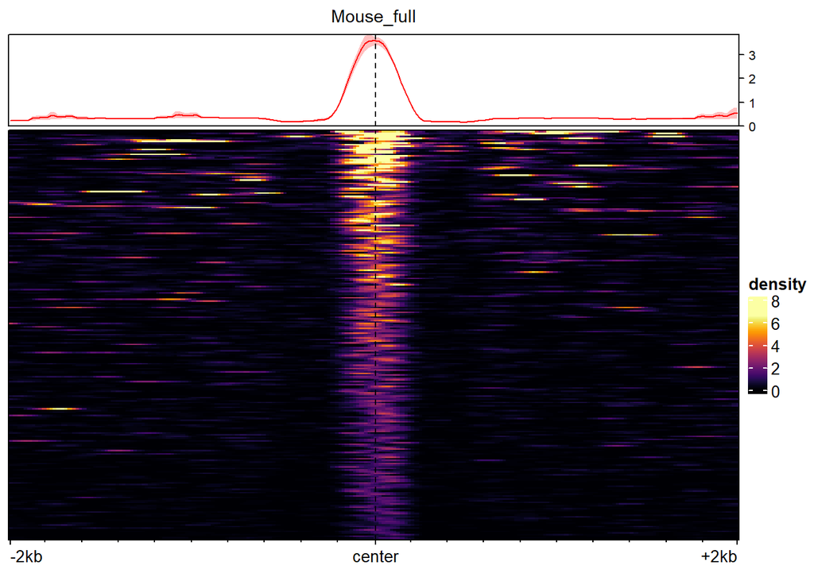

```r
plotEnrichedHeatmaps(peakSignals, raster_by_magick=FALSE)
```

# Of the p300 peaks what proportion overlap each of the marks?

## Start with H3K4me3

```r
h3k4me3 <- rtracklayer::import("C:/Users/Sarah.HOME/OneDrive/ETH/Master/Neuro FS22/Bioinformatic approaches to regulatory genomics/Assignments/Week 3/encode/H3K4me3.bed.gz", format = "narrowPeak")
#We need to specify that it is a narrowPeak format because otherwhise it assumes differently
#This gives me an error saying there are no sequence levels in common, so I have to rename the sequence levels for it to work.
#sub and gsub perform replacement of the first and all matches respectively.
h3k4me3 <- renameSeqlevels(x = h3k4me3, levels(gsub("chr", "", seqnames(h3k4me3))))
p300h3k4me3 <- overlapsAny(peaks, h3k4me3)
#just ignore the warning it gives you
#The output is a logical vector with the length of the number of peaks
#you can ask the other way around and then get a logical vector with the length of the number of h3k4me3
#to calculate what proportion overlaps each of the marks
sum(p300h3k4me3)/length(p300h3k4me3)
```

```
## [1] 0.4592291
```

Overlap: 0.459

## H3K4me1

```r
h3k4me1 <- rtracklayer::import("C:/Users/Sarah.HOME/OneDrive/ETH/Master/Neuro FS22/Bioinformatic approaches to regulatory genomics/Assignments/Week 3/encode/H3K4me1.bed.gz", format = "narrowPeak")
h3k4me1 <- renameSeqlevels(x = h3k4me1, levels(gsub("chr", "", seqnames(h3k4me1))))
p300h3k4me1 <- overlapsAny(peaks, h3k4me1)
sum(p300h3k4me1)/length(p300h3k4me1)
```

```
## [1] 0.1773649
```

Overlap: 0.177

## H3K27ac

```r
h3k27ac <- rtracklayer::import("C:/Users/Sarah.HOME/OneDrive/ETH/Master/Neuro FS22/Bioinformatic approaches to regulatory genomics/Assignments/Week 3/encode/H3K27ac.bed.gz", format = "narrowPeak")
h3k27ac <- renameSeqlevels(x = h3k27ac, levels(gsub("chr", "", seqnames(h3k27ac))))
p300h3k27ac <- overlapsAny(peaks, h3k27ac)
sum(p300h3k27ac)/length(p300h3k27ac)
```

```
## [1] 0.4864865
```

Overlap: 0.486

## H3K27me3

```r
h3k27me3 <- rtracklayer::import("C:/Users/Sarah.HOME/OneDrive/ETH/Master/Neuro FS22/Bioinformatic approaches to regulatory genomics/Assignments/Week 3/encode/H3K27me3.bed.gz", format = "narrowPeak")
h3k27me3 <- renameSeqlevels(x = h3k27me3, levels(gsub("chr", "", seqnames(h3k27me3))))
p300h3k27me3 <- overlapsAny(peaks, h3k27me3)
sum(p300h3k27me3)/length(p300h3k27me3)
```

```
## [1] 0.1114097
```

Overlap: 0.111

Estimated time for assignment completion: 2.5 hours